# High Performance Computing - 2: fasteR

# Simple things to make R go fasteR

This section will review a couple of simple things one can do to make R go fasteR.

# Better Computer

How fast is your computer may be a sensitive question for many, yet this is one of the most obvious ways to make R functions run faster. A good starting point is to figure out whether your computer is slow or fast. Of course, there is a package for that.

## library(benchmarkme)

This library will not only pull up hardware specs but also compare your computer to others machines.

```r
library(benchmarkme)
get_ram()
```

```
## NA B
```

```r
get_cpu()
```

```
## $vendor_id
## [1] "GenuineIntel"
##
## $model_name
## [1] "Intel(R) Core(TM) i7-8650U CPU @ 1.90GHz"
##
## $no_of_cores
## [1] 8
```

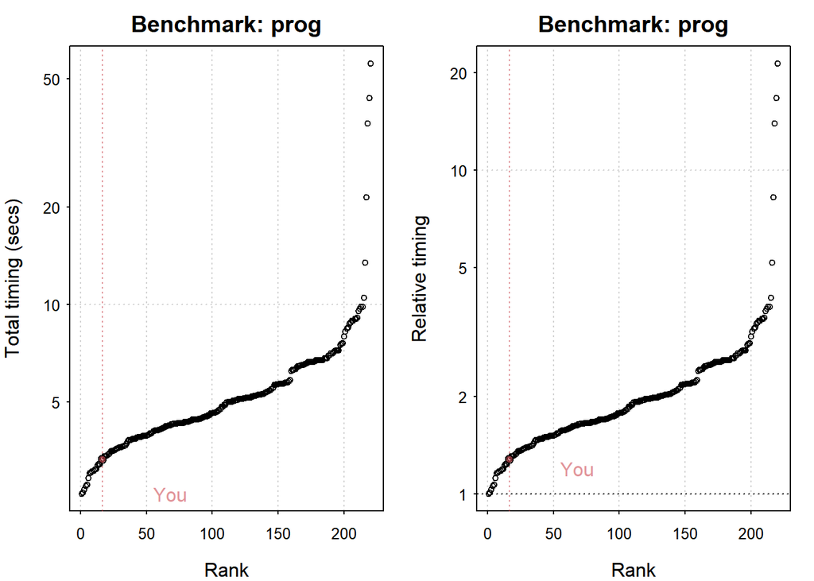

```
## Press return to get next plot
```

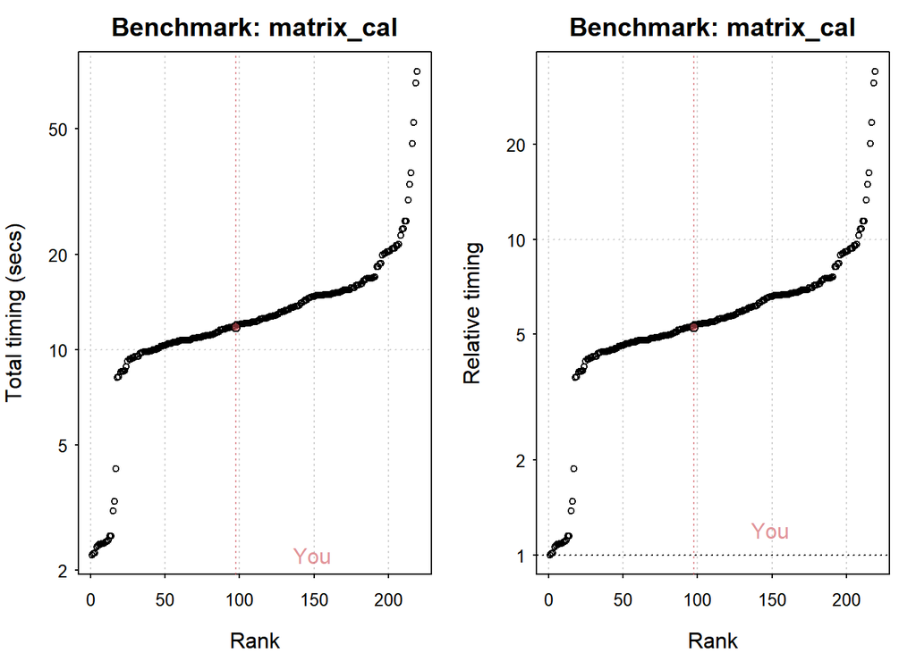

```
## Press return to get next plot
```

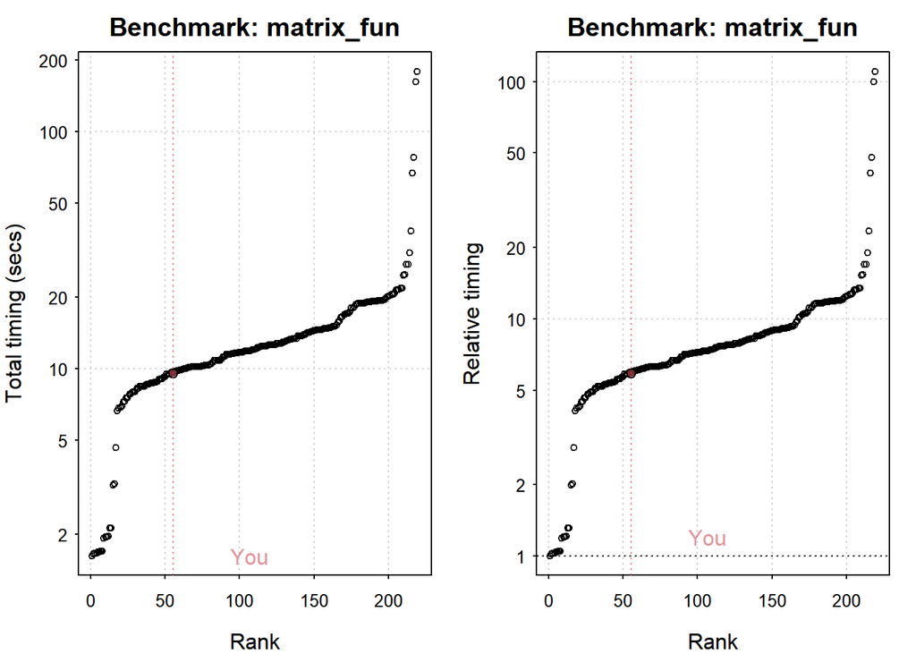

```r
speedResult = benchmark_std(runs = 3)
plot(speedResult)
```

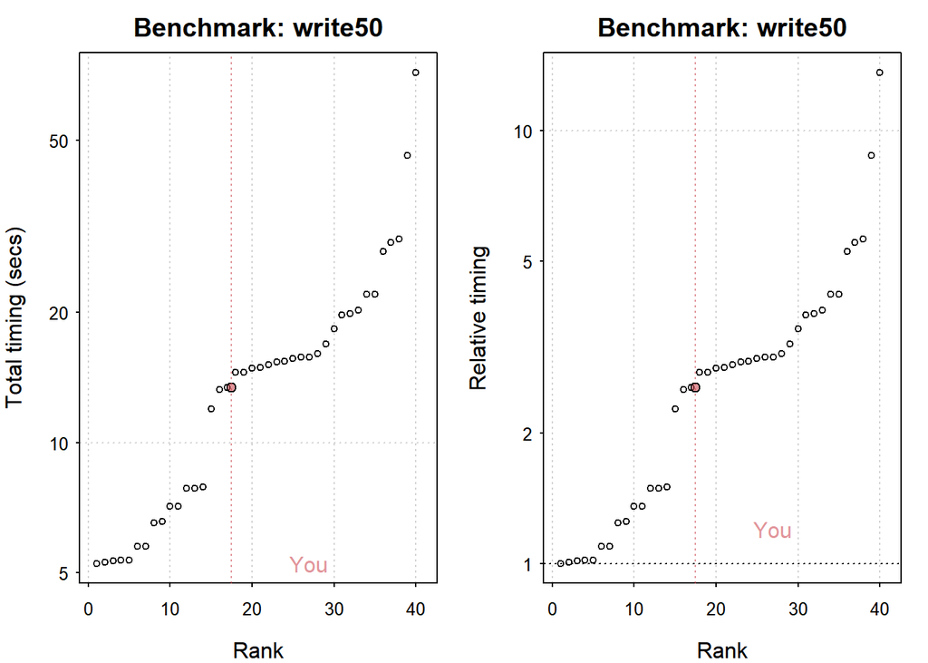

```
## Press return to get next plot
```

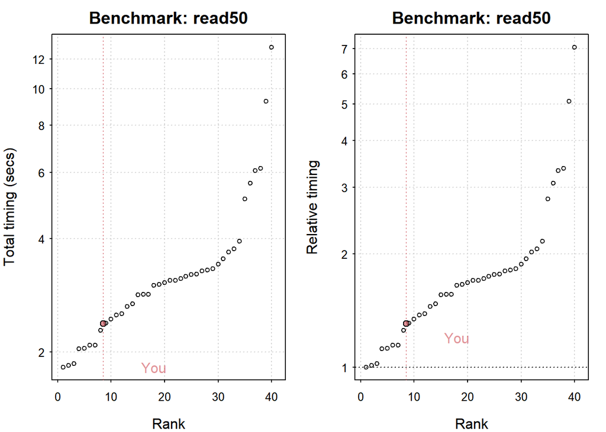

```r
speed_io = benchmark_io(runs=3,size = 50)
plot(speed_io)
```

# Vectorization (over loops)

Vectorized operations involve applying a function once to an entire vector. On the other hand, a loop will apply the function to each element n times.

Loop

```r
num = sample(1:10,size=1e7,replace=T)
num_square = integer(length(num))

system.time(for (i in 1:length(num)){
  num_square[i] = num[i]^2
})
```

```
##    user  system elapsed
##    0.51    0.00    0.52
```

Vectorized operation

```r
system.time(num_squared <- num^2)
```

```
##    user  system elapsed
##    0.04    0.00    0.03
```

# Use built-in functions

Many R functions and packages are implemented in compiled languages like C/C++ These will always run faster than functions written in R, an interpreted language

```r
data = sample(1:10,size = 1e7,replace=T)
dim(data) = c(100000,100)

system.time(apply(X=data,MARGIN = 2,FUN = sum))
```

```
##    user  system elapsed
##     0.1     0.0     0.1
```

```r
system.time(colSums(data))
```

```
##    user  system elapsed
##       0       0       0
```

```r
library(microbenchmark)
microbenchmark(apply = apply(X=data,MARGIN = 2,FUN = sum),colSums = colSums(data))
```

| expr | time |
| --- | --- |
| colSums | 7675301 |
| colSums | 7605801 |
| colSums | 7847501 |
| colSums | 9192901 |
| colSums | 8248201 |
| colSums | 8075301 |
| colSums | 7544200 |
| colSums | 7625601 |
| apply | 89385102 |
| colSums | 7489801 |

[output cut: 190 more lines]

# Use faster functions

Certain functions are faster, possibly because they are optimized in C++ or because of more efficient ways processes. `aggregate`, `tapply`, `dplyr`, and `data.table` are all ways of summarizing data, but there are differences in performance.

```r
library(ggplot2)
library(dplyr)
str(diamonds)
```

```
## Classes 'tbl_df', 'tbl' and 'data.frame':    53940 obs. of  10 variables:
##  $ carat  : num  0.23 0.21 0.23 0.29 0.31 0.24 0.24 0.26 0.22 0.23 ...
##  $ cut    : Ord.factor w/ 5 levels "Fair"<"Good"<..: 5 4 2 4 2 3 3 3 1 3 ...
##  $ color  : Ord.factor w/ 7 levels "D"<"E"<"F"<"G"<..: 2 2 2 6 7 7 6 5 2 5 ...
##  $ clarity: Ord.factor w/ 8 levels "I1"<"SI2"<"SI1"<..: 2 3 5 4 2 6 7 3 4 5 ...
##  $ depth  : num  61.5 59.8 56.9 62.4 63.3 62.8 62.3 61.9 65.1 59.4 ...
##  $ table  : num  55 61 65 58 58 57 57 55 61 61 ...
##  $ price  : int  326 326 327 334 335 336 336 337 337 338 ...
##  $ x      : num  3.95 3.89 4.05 4.2 4.34 3.94 3.95 4.07 3.87 4 ...
##  $ y      : num  3.98 3.84 4.07 4.23 4.35 3.96 3.98 4.11 3.78 4.05 ...
##  $ z      : num  2.43 2.31 2.31 2.63 2.75 2.48 2.47 2.53 2.49 2.39 ...
```

```r
data = diamonds[sample(1:nrow(diamonds),size = 1e6,replace=T),]
system.time(aggregate(price~cut,data,mean))
```

```
##    user  system elapsed
##    0.22    0.02    0.23
```

```r
system.time(tapply(data$price,data$cut,mean))
```

```
##    user  system elapsed
##    0.01    0.00    0.02
```

```r
system.time(data%>%
              group_by(cut)%>%
              summarize(price=mean(price)))
```

```
##    user  system elapsed
##    0.00    0.01    0.02
```

```r
library(data.table)
dt = data.table(data)
system.time(dt[,mean(price),by='cut'])
```

```
##    user  system elapsed
##    0.01    0.05    0.02
```

```r
microbenchmark(aggregate = aggregate(price~cut,data,mean),
               tapply = tapply(data$price,data$cut,mean),
               dplyr = data%>% group_by(cut)%>% summarize(price=mean(price)),
               data.table = dt[,mean(price),by='cut'],times = 5)
```

| expr | time |
| --- | --- |
| dplyr | 17717201 |
| data.table | 18164701 |
| data.table | 19740100 |
| aggregate | 230006501 |
| data.table | 19317501 |
| tapply | 14204801 |
| tapply | 14615401 |
| tapply | 17251001 |
| tapply | 105667902 |
| dplyr | 18102301 |

[output cut: 10 more lines]

# Pre-allocate memory

In programming languages like C, C++, or Java, a vector (or array) has to be declared prior to its use. Declaring in effect preallocates memory space.

In R, this happens automatically. But, if the memory allocated is not large enough, then R will have to create a larger space and move the data to the larger memory space. This reallocation based on need can slow things down, especially if it is done repeatedly for each additional element. Manually allocating memory can save R some time.

## Memory not preallocated

```r
numbers = sample(1:10,size=1e6,replace=T)
num_square =
  function(num){
  num_square = integer()
    for (i in 1:length(num)){
      num_square[i] = num[i]^2
  }
}
system.time(num_square(numbers))
```

```
##    user  system elapsed
##    0.20    0.00    0.21
```

## Memory preallocated

```r
num_square_preallocated =
  function(num){
    num_square = integer(length(num))
      for (i in 1:length(num)){
        num_square[i] = num[i]^2
    }
  }
system.time(num_square_preallocated(numbers))
```

```
##    user  system elapsed
##    0.07    0.00    0.07
```

```r
microbenchmark(num_square(numbers),num_square_preallocated(numbers),times = 5)
```

| expr | time |
| --- | --- |
| num_square(numbers) | 190901101 |
| num_square_preallocated(numbers) | 49786801 |
| num_square(numbers) | 193934701 |
| num_square_preallocated(numbers) | 51626701 |
| num_square(numbers) | 187538600 |
| num_square_preallocated(numbers) | 55104001 |
| num_square_preallocated(numbers) | 58969100 |
| num_square(numbers) | 192658600 |
| num_square_preallocated(numbers) | 50937201 |
| num_square(numbers) | 195763601 |

```r
numbersX10 = sample(1:10,size=1e7,replace=T)
numbersX50 = sample(1:10,size=5e7,replace=T)

microbenchmark(num_square(numbers),num_square_preallocated(numbers),
               num_square(numbersX10),num_square_preallocated(numbersX10),
               num_square(numbersX50),num_square_preallocated(numbersX50), times = 5)
```

| expr | time |
| --- | --- |
| num_square(numbersX50) | 13366804901 |
| num_square(numbers) | 219064501 |
| num_square_preallocated(numbersX50) | 3037577301 |
| num_square_preallocated(numbersX10) | 553701701 |
| num_square_preallocated(numbersX10) | 631782900 |
| num_square(numbers) | 382862201 |
| num_square(numbersX50) | 12623059700 |
| num_square(numbersX10) | 2397698801 |
| num_square(numbersX10) | 2355246501 |
| num_square(numbers) | 208186201 |

[output cut: 20 more lines]

Another Example

```r
s3 = function(n) {
  sum = numeric()
  for (i in 1:n){
    sum = sum+i
  }
  sum
}
system.time(s3(1e6))
```

```
##    user  system elapsed
##    0.06    0.00    0.06
```

```r
s3_preallocate = function(n) {
  sum = numeric(length(n))
  for (i in 1:n){
    sum = sum+i
  }
  sum
}
system.time(s3_preallocate(1e6))
```

```
##    user  system elapsed
##    0.03    0.00    0.03
```

```r
microbenchmark(s3(1e6),s3_preallocate(1e6),times = 10)
```

| expr | time |
| --- | --- |
| s3(1e+06) | 51936601 |
| s3_preallocate(1e+06) | 18946601 |
| s3(1e+06) | 57496901 |
| s3(1e+06) | 55418900 |
| s3(1e+06) | 61898301 |
| s3_preallocate(1e+06) | 24002600 |
| s3_preallocate(1e+06) | 20311801 |
| s3(1e+06) | 55558600 |
| s3_preallocate(1e+06) | 20611101 |
| s3(1e+06) | 55474901 |

[output cut: 10 more lines]

# Use simpler data structures

For instance, if all the data is of the same class, it is better to use a matrix rather than data.frame. Also, data.table may not always be the fastest

```r
mat = sample(1:10,size = 1e8,replace=T)
dim(mat) = c(100000,1000)
system.time(colSums(mat))
```

```
##    user  system elapsed
##    0.13    0.11    0.23
```

```r
df = data.frame(mat)
system.time(colSums(df))
```

```
##    user  system elapsed
##    0.25    0.04    0.29
```

```r
microbenchmark(matrix = colSums(mat),data.frame = colSums(df),times = 10)
```

| expr | time |
| --- | --- |
| data.frame | 273923101 |
| data.frame | 346015802 |
| matrix | 89216302 |
| data.frame | 323116400 |
| matrix | 86883601 |
| matrix | 87225502 |
| matrix | 87473601 |
| data.frame | 408929402 |
| data.frame | 293492801 |
| data.frame | 353938900 |

[output cut: 10 more lines]

```r
microbenchmark(matrix = mat[,100],   data.frame = df[,100],times=10) # Subsetting col 100
```

| expr | time |
| --- | --- |
| data.frame | 49600 |
| data.frame | 9401 |
| matrix | 329000 |
| matrix | 283501 |
| data.frame | 10701 |
| matrix | 286000 |
| matrix | 320401 |
| matrix | 302402 |
| matrix | 285201 |
| data.frame | 16901 |

[output cut: 10 more lines]

```r
microbenchmark(matrix = mat[100,],   data.frame = df[100,],times=10) # Subsetting row 100
```

| expr | time |
| --- | --- |
| matrix | 54800 |
| data.frame | 5397801 |
| data.frame | 4113701 |
| matrix | 50901 |
| data.frame | 4603201 |
| matrix | 48501 |
| matrix | 7301 |
| matrix | 5901 |
| data.frame | 4514101 |
| matrix | 47900 |

[output cut: 10 more lines]

```r
microbenchmark(matrix = mat[100,100],data.frame = df[100,100],times=10) # Subsetting row 100, col 100
```

| expr | time |
| --- | --- |
| matrix | 5601 |
| data.frame | 71002 |
| data.frame | 20301 |
| data.frame | 15801 |
| matrix | 301 |
| data.frame | 16301 |
| data.frame | 15101 |
| matrix | 200 |
| matrix | 102 |
| matrix | 101 |

[output cut: 10 more lines]

```r
library(dplyr)
library(data.table)
dt = data.table(mat)
system.time(colSums(dt))
```

```
##    user  system elapsed
##    0.26    0.01    0.28
```

```r
dplyr_df = as_data_frame(mat)
system.time(colSums(dplyr_df))
```

```
##    user  system elapsed
##    0.22    0.07    0.28
```

```r
microbenchmark(matrix = colSums(mat),data.frame = colSums(df),data.table = colSums(dt), dplyr = colSums(dplyr_df),times = 10)
```

| expr | time |
| --- | --- |
| dplyr | 288481401 |
| matrix | 92460500 |
| matrix | 96855501 |
| data.frame | 337222400 |
| data.frame | 383721001 |
| data.table | 279456101 |
| data.frame | 463402201 |
| data.table | 279408101 |
| dplyr | 296497401 |
| matrix | 86647300 |

[output cut: 30 more lines]

```r
microbenchmark(matrix = mat[100,100],data.frame = df[100,100],data.table = dt[100,100],dplyr = dplyr_df[100,100],times=10) # Subsetting row 100, col 100
```

| expr | time |
| --- | --- |
| data.frame | 65100 |
| data.table | 1615001 |
| matrix | 2501 |
| data.frame | 36900 |
| data.table | 830401 |
| matrix | 1001 |
| dplyr | 216101 |
| matrix | 501 |
| data.table | 595202 |
| matrix | 1001 |

[output cut: 30 more lines]

# Use hash tables

```r
data = rnorm(1E4)
data_ls = as.list(data)
names(data_ls) = paste("V", c(1:1E4), sep="")
index_rand = sample(1:1E4, size=1000, replace=T)
index = paste("V", index_rand, sep="")
list_comptime = sapply(index, FUN=function(x){
  system.time(data_ls[[x]])[3]})
sum(list_comptime)
```

```
## [1] 0.02
```

```r
library(hash)
data_h = hash(names(data_ls), data)
hash_comptime = sapply(index, FUN=function(x){
  system.time(data_h[[x]])[3]})
sum(hash_comptime)
```

```
## [1] 0.02
```

# Use faster, more efficient packages

In this example, you will note that fastcluster gives better performance than the clustering algorithm in the stats package. On the other hand, Rcppeigen did not do any better than lm.

```r
data = rnorm(1e4*100)
dim(data) = c(1e4,100)
dist_data = dist(data)

system.time(hclust(dist_data))
```

```
##    user  system elapsed
##    3.02    0.05    3.07
```

```r
library(fastcluster)
system.time(hclust(dist_data))
```

```
##    user  system elapsed
##    1.41    0.15    1.57
```

```r
data = rnorm(10000*100)
dim(data) = c(10000,100)
#princomp(data)
#prcomp(data)
microbenchmark(princomp(data),prcomp(data),times=5)
```

| expr | time |
| --- | --- |
| princomp(data) | 155187001 |
| princomp(data) | 152927601 |
| prcomp(data) | 293251401 |
| prcomp(data) | 275054601 |
| prcomp(data) | 302733701 |
| prcomp(data) | 304714601 |
| princomp(data) | 150365101 |
| princomp(data) | 144310401 |
| princomp(data) | 143729701 |
| prcomp(data) | 268183201 |

```r
library(ggplot2)
data = diamonds[sample(1:nrow(diamonds),size = 1e6,replace=T),]
system.time(lm(price~.,data))
```

```
##    user  system elapsed
##    1.09    0.03    1.12
```

```r
library(RcppEigen)
x = model.matrix(price~.-1,data)
y = data$price

fast = function(dataframe){
  library(RcppEigen)
  x = model.matrix(price~.-1,data)
  y = data$price
  fastLm(x,y)
}

microbenchmark(lm(price~.,data),fast(data),times=5)
```

| expr | time |
| --- | --- |
| lm(price ~ ., data) | 1081682201 |
| fast(data) | 1385191401 |
| lm(price ~ ., data) | 1146359701 |
| fast(data) | 1476322002 |
| fast(data) | 1415816901 |
| lm(price ~ ., data) | 1383254701 |
| fast(data) | 1413201001 |
| fast(data) | 1508554002 |
| lm(price ~ ., data) | 1075098100 |
| lm(price ~ ., data) | 1166053201 |